# Formula 1

Jo Hardin

9/7/2021

## The Data

The data this week comes from the [Ergast API](https://ergast.com/mrd/db/#csv), which has a CC-BY license. H/t to [Sara Stoudt](https://github.com/rfordatascience/tidytuesday/issues/372) for sharing the link to the data by way of [Data is Plural](https://www.data-is-plural.com/archive/2021-08-25-edition/)!

```r
lap_times <- readr::read_csv("lap_times.csv", na = c("", "NA", "\\N"))
races <- readr::read_csv("races.csv", na = c("", "NA", "\\N"))
results <- readr::read_csv("results.csv", na = c("", "NA", "\\N"))
constructors <- readr::read_csv("constructors.csv", na = c("", "NA", "\\N"))
```

## Investigating the data

The ideas for combining the datasets and looking at race time come from: https://github.com/nrennie/tidytuesday/tree/main/2021/07-09-2021

```r
races_joined <- left_join(left_join(dplyr::filter(results, positionText == 1), races, by = "raceId"),
                                    constructors, by = "constructorId") %>%
  mutate(win_time = milliseconds / laps) %>%
  select(resultId, constructorId, laps, milliseconds, fastestLap,
         fastestLapSpeed, year, name.x, win_time, nationality) %>%
  filter(name.x %in% c("Monaco Grand Prix", "British Grand Prix", "Italian Grand Prix", "French Grand Prix", "German Grand Prix")) %>%
  filter(constructorId %in% c(1, 3, 6, 32, 131))

mean_races <- races_joined %>% group_by(year) %>%
  summarize(mean_ms = mean(as.numeric(milliseconds)),
            mean_win = mean(as.numeric(win_time)))
```

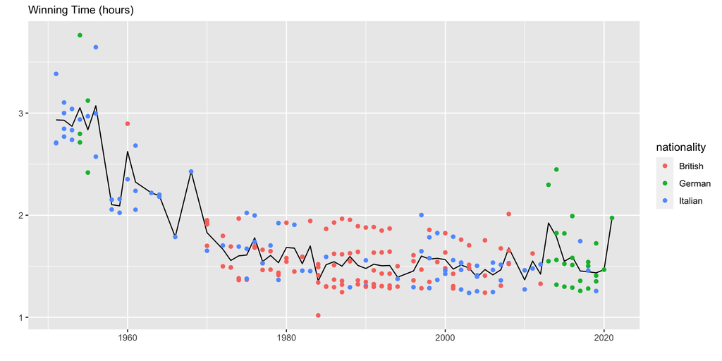

```r
ggplot() +
  geom_line(mean_races,
            mapping = aes(x = year, y = mean_ms/1000/60/60), color = "black") +
  geom_point(races_joined,
             mapping = aes(x = year, y = as.numeric(milliseconds)/1000/60/60,
                          color = nationality)) +
  labs(x = "", y = "", subtitle = "Winning Time (hours)")
```

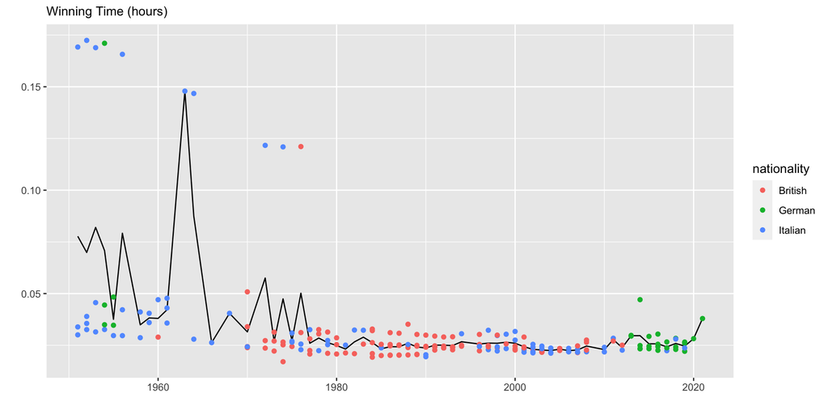

```r
ggplot() +
  geom_line(mean_races, mapping = aes(x = year, y = mean_win/1000/60/60), color = "black") +
  geom_point(races_joined, mapping = aes(x = year, y = as.numeric(win_time)/1000/60/60, color = nationality)) +
  labs(x = "", y = "", subtitle = "Winning Time (hours)")
```

## Tidy model to predict win_time

#### data split

```r
set.seed(4747)
formula1_split <- races_joined %>%
  drop_na() %>%
  initial_split()

formula1_train <- training(formula1_split)
formula1_test <- testing(formula1_split)
```

#### recipe

```r
formula1_recipe <- recipe(win_time ~., data = formula1_train) %>%
  update_role(resultId, new_role = "ID") %>%
  step_dummy(name.x, nationality, constructorId) %>%
  step_rm(milliseconds)

formula1_recipe
```

```
## Data Recipe
##
## Inputs:
##
##       role #variables
##         ID          1
##    outcome          1
##  predictor          8
##
## Operations:
##
## Dummy variables from name.x, nationality, constructorId
## Delete terms milliseconds
```

#### set a model

```r
formula1_mod <- rand_forest(
  mtry = 4,
  trees = 100,
  min_n = 3) %>%
  set_mode("regression") %>%
  set_engine("ranger")
```

#### alternative model setting

if the plan is to tune hyperparameters, then use `tune()` for the parameters:

```r
formula1_mod_tune <- rand_forest(
  mtry = tune(),
  trees = 100,
  min_n = tune()) %>%
  set_mode("regression") %>%
  set_engine("ranger")
```

#### build workflow

```r
formula1_wf1 <- workflow() %>%
  add_recipe(formula1_recipe) %>%
  add_model(formula1_mod)

formula1_wf1
```

```
## ══ Workflow ════════════════════════════════════════════════════════════════════
## Preprocessor: Recipe
## Model: rand_forest()
##
## ── Preprocessor ────────────────────────────────────────────────────────────────
## 2 Recipe Steps
##
## • step_dummy()
## • step_rm()
##
## ── Model ───────────────────────────────────────────────────────────────────────
## Random Forest Model Specification (regression)
##
## Main Arguments:
##   mtry = 4
##   trees = 100
##   min_n = 3
##
## Computational engine: ranger
```

### fit model

```r
formula1_results <- formula1_wf1 %>%
  fit(data = formula1_train)

formula1_results
```

```
## ══ Workflow [trained] ══════════════════════════════════════════════════════════
## Preprocessor: Recipe
## Model: rand_forest()
##
## ── Preprocessor ────────────────────────────────────────────────────────────────
## 2 Recipe Steps
##
## • step_dummy()
## • step_rm()
##
## ── Model ───────────────────────────────────────────────────────────────────────
## Ranger result
##
## Call:
##  ranger::ranger(x = maybe_data_frame(x), y = y, mtry = min_cols(~4,      x), num.trees = ~100, min.node.size = min_rows(~3, x), num.threads = 1,      verbose = FALSE, seed = sample.int(10^5, 1))
##
## Type:                             Regression
## Number of trees:                  100
## Sample size:                      37
## Number of independent variables:  11
## Mtry:                             4
## Target node size:                 3
## Variable importance mode:         none
## Splitrule:                        variance
## OOB prediction error (MSE):       239116501
## R squared (OOB):                  0.2423603
```

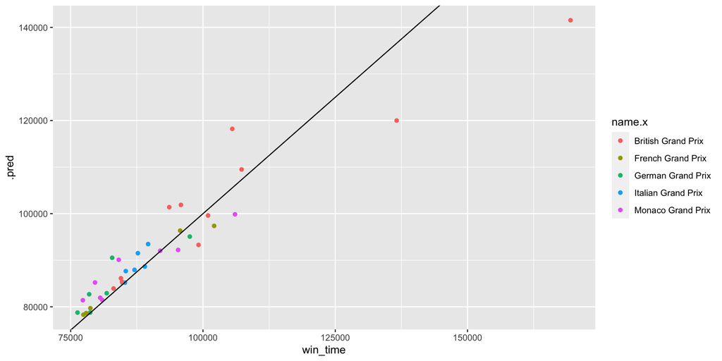

```r
formula1_results %>% predict(new_data = formula1_train) %>% cbind(formula1_train) %>%
  ggplot() +
  geom_point(aes(x = win_time, y = .pred, color = name.x)) +
  geom_abline(slope = 1, intercept = 0)
```

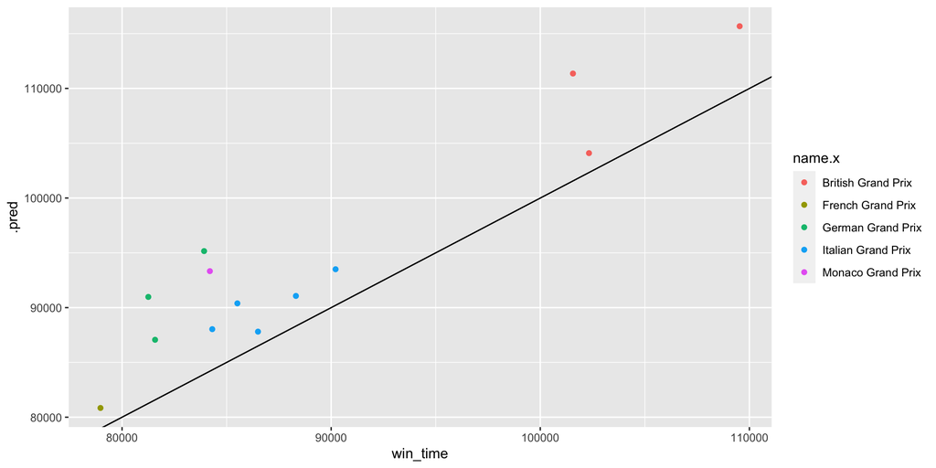

```r
formula1_results %>% predict(new_data = formula1_test) %>% cbind(formula1_test) %>%
  ggplot() +
  geom_point(aes(x = win_time, y = .pred, color = name.x)) +
  geom_abline(slope = 1, intercept = 0)
```

## reflection

model wasn’t great. but i’m going to call this activity a win because i was able to build a pretty straightforward model that did predict the per-lap winning time to some degree. note that because we wanted a complete dataset (no missing values) with a bunch of variables, the dataset got much smaller! 37 training points and 13 test points isn’t much to do model building.

```r
praise()
```

```
## [1] "You are wonderful!"
```